# SASC: Hooke Part 1, Silicosis

April 8, 2026

# Differential abundance

Hooke can identify differentially abundant cell types for a given contrast. The underlying PLN model mimics the standard `R::stats` GLM-like interface. This allows users to fit a multivariate Poisson lognormal model after correcting for effects of offsets and covariates. This framework allows users to perform multivariate statistical regression to describe how perturbations alter the relative abundances of each cell state. For example, you could model the effects of genotype while controlling for experimental batch.

## Analysis of differentially abundant cell types in silicosis with Hooke

These data were published in [Hasegawa, Franks, et al. *bioRxiv*](https://www.biorxiv.org/content/10.1101/2023.02.17.528996v1). The authors performed a longitudinal transcriptomic analysis using scRNA-sequencing of lungs from pre- and post-silica challenged mice.

The data includes 12 whole lung samples across pre- and post-intratracheal silica. Thirty-five unique cell states were identified using highly and specifically expressed marker genes. For simplicity, samples are grouped into two levels: exposed and not exposed. The goal is to identify which cell types are differentially abundant after silica exposure.

Download the data: [Silicosis data (.RDS)](https://depts.washington.edu/trapnell-lab/software/hooke/silicosis_cds.rds)

### Cell metadata breakdown

Important columns in this data:

- `ID` - individual sample ID.
- `Timepoint` - timepoint at which the lung was sampled.
- `Rep` - biological replicate
- `fine_annotation` - The finest cell type annotation level.
- `broad_annotation` - A broader level of cell type annotation than `cell_type_sub`, but still capturing all uniquely identified cell types.

The next chunk loads the silicosis dataset, creates a simplified exposure label, and visualizes the annotated cell states.

```r
library(monocle3)
```

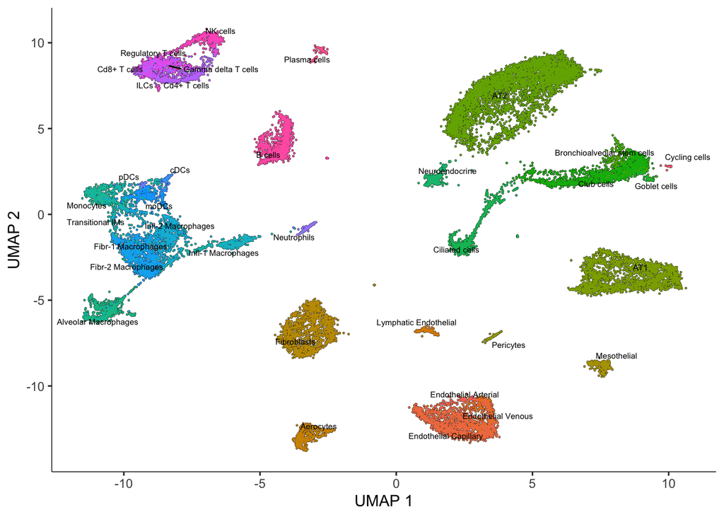

```r
library(hooke)
library(tidyverse)
cds <- readRDS("silicosis_cds.rds")

# For simplicity, lump together pre and post i.t. silica.
colData(cds)$exposed <- ifelse(colData(cds)$Timepoint == 0, "not exposed", "exposed")
colData(cds)$Rep <- as.factor(colData(cds)$Rep)

plot_cells(cds, color_cells_by = "fine_annotation", label_groups_by_cluster = FALSE)
```

### Making a cell count set object

The first step in Hooke is to create a `cell_count_set` object. This requires three inputs:

- `cds`: a monocle3 `cell_data_set` object
- `sample_group`: a column in `colData(cds)` that specifies how cells are grouped into samples
- `cell_group`: a column in `colData(cds)` that specifies how cells are grouped into cell types or states

```r
ccs <- new_cell_count_set(
    cds,
    sample_group = "ID",
    cell_group = "fine_annotation"
)
```

The resulting `ccs` object stores cell counts for each cell group within each sample and serves as the main input for downstream Hooke modeling.

### Fitting a cell count model

The next step is to fit a `cell_count_model` given a model formula. This function uses standard R formula notation.

A cell count model requires the following inputs:

- `ccs`: a Hooke `cell_count_set` object
- `main_model_formula_str`: a character string specifying the model of cell abundances across samples, where terms refer to columns in `colData(ccs)`
- `nuisance_model_formula_str`: a character string specifying nuisance effects across samples
- `vhat_method`: method used to estimate the variance-covariance matrix of the model coefficients.
- `num_bootstraps`: number of bootstraps to perform if `vhat_method` is “bootstrap”

In this example, the comparison of interest is silica-exposed mouse lungs versus unexposed lungs.

```r
ccm <- new_cell_count_model(
    ccs,
    main_model_formula_str = "~ exposed",
    vhat_method = "bootstrap",
    num_bootstraps = 10
)
```

```
#> [1] "fitting model with 1 threads"
```

### Estimating abundances

Next, predict abundance values for a contrast of interest using `estimate_abundances()`. These are model-based estimated abundances for each cell group under each condition, not the raw observed cell counts from the dataset.

- `ccm`: a Hooke `cell_count_model` object
- `newdata`: a tibble of variables used for the prediction
- `min_log_abund`: numeric minimum log abundance value

```r
cond_exp <- estimate_abundances(ccm, tibble::tibble(exposed = "exposed"))
cond_not_exp <- estimate_abundances(ccm, tibble::tibble(exposed = "not exposed"))

cond_not_exp %>% head()
```

```
#> # A tibble: 6 × 5
#>   exposed     cell_group            log_abund log_abund_se log_abund_sd
#>   <chr>       <chr>                     <dbl>        <dbl>        <dbl>
#> 1 not exposed Endothelial Arterial       2.71       0.110         0.559
#> 2 not exposed Endothelial Capillary      5.15       0.0502        0.559
#> 3 not exposed Endothelial Venous         2.94       0.0514        0.559
#> 4 not exposed Lymphatic Endothelial      2.47       0.312         0.559
#> 5 not exposed Aerocytes                  3.90       0.0592        0.559
#> 6 not exposed Fibroblasts                5.11       0.0508        0.559
```

### Comparing abundances

We can then compare two estimated abundance states from a Hooke model with `compare_abundances()`. In this case, we compare exposed versus not exposed. This step estimates differential abundance between the two predicted conditions.

- `ccm`: a Hooke `cell_count_model` object
- `cond_x`: a cell type abundance estimate from `estimate_abundances()`
- `cond_y`: a cell type abundance estimate from `estimate_abundances()`

```r
cond_ne_v_e_tbl <- compare_abundances(ccm, cond_not_exp, cond_exp)

cond_ne_v_e_tbl %>%
    dplyr::select(
        cell_group,
        exposed_x,
        exposed_y,
        delta_log_abund,
        delta_log_abund_se,
        delta_q_value
    ) %>%
    head()
```

```
#> # A tibble: 6 × 6
#>   cell_group            exposed_x   exposed_y delta_log_abund delta_log_abund_se
#>   <chr>                 <chr>       <chr>               <dbl>              <dbl>
#> 1 Endothelial Arterial  not exposed exposed           -0.584              0.190
#> 2 Endothelial Capillary not exposed exposed           -0.400              0.0991
#> 3 Endothelial Venous    not exposed exposed           -0.353              0.148
#> 4 Lymphatic Endothelial not exposed exposed            0.0529             0.337
#> 5 Aerocytes             not exposed exposed           -0.354              0.144
#> 6 Fibroblasts           not exposed exposed           -0.477              0.107
#> # ℹ 1 more variable: delta_q_value <dbl>
```

### Plotting differential abundance changes on a UMAP

We can visualize these fold changes estimated in `compare_abundances()` on a UMAP using `plot_contrast()`. Significant fold changes can be filtered with `q_value_thresh`. In this plot, we can identify cell groups that are enriched or depleted in exposed lungs relative to unexposed lungs.

- `ccm`: a Hooke `cell_count_model` object
- `cond_b_vs_a_tbl`: a data frame returned by `compare_abundances()`
- `log_abundance_thresh`: numeric threshold used to select cell groups by abundance
- `q_value_thresh`: remove contrasts whose q-value exceeds this threshold

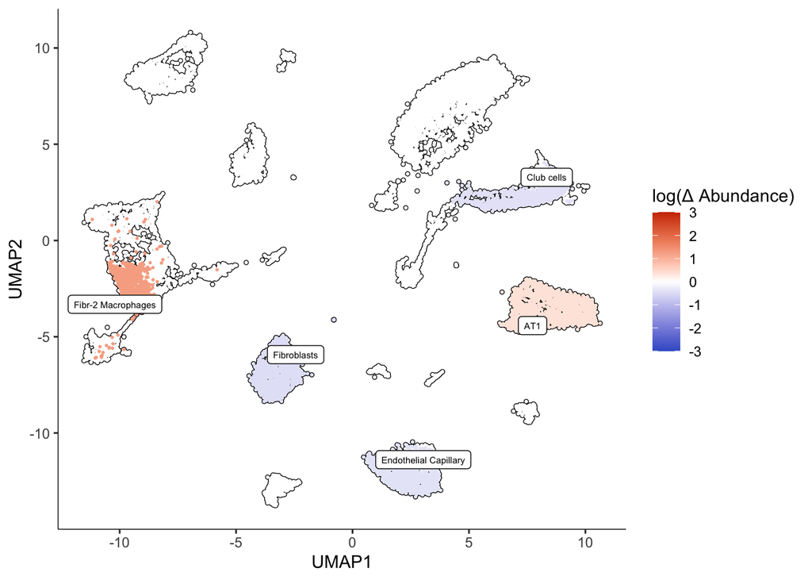

```r
plot_contrast(ccm, cond_ne_v_e_tbl, q_value_thresh = 0.05)
```